# Healthcare Feature Engineering

## Objectives

It is important in any data science project to define the objective as specific as possible. Below let's write it from general to specific. This will direct your analysis.

- Detect any hospital that may abuse the resources.
- Detect any hospital that may abuse the resources compared to its peers.
- Detect any hospital that may abuse the resources compared to the average (median etc) of its peers.
- Detect any hospital that may abuse the resources compared to the average (median etc) of its peers of the same DRG and State.

## Section 1: Data preparation

### Section 1.1: Load Data

- Import packages and data
- Rename column
- Change data type and transfer spending amount with dollar sign into numeric
- Understand the data strcuture.

```python
import pandas as pd
import numpy as np
import matplotlib.pyplot as plt
import seaborn as sns
%matplotlib inline
```

```python
data = pd.read_csv('inpatientCharges.csv')
#data.head()
#data.describe
data.info()
```

```
<class 'pandas.core.frame.DataFrame'>
RangeIndex: 163065 entries, 0 to 163064
Data columns (total 12 columns):
 #   Column                                Non-Null Count   Dtype
---  ------                                --------------   -----
 0   DRG Definition                        163065 non-null  object
 1   Provider Id                           163065 non-null  int64
 2   Provider Name                         163065 non-null  object
 3   Provider Street Address               163065 non-null  object
 4   Provider City                         163065 non-null  object
 5   Provider State                        163065 non-null  object
 6   Provider Zip Code                     163065 non-null  int64
 7   Hospital Referral Region Description  163065 non-null  object
 8    Total Discharges                     163065 non-null  int64
 9    Average Covered Charges              163065 non-null  object
 10   Average Total Payments               163065 non-null  object
 11  Average Medicare Payments             163065 non-null  object
dtypes: int64(3), object(9)
memory usage: 14.9+ MB
```

```python
data.columns = ['DRG','Provider_Id', 'Provider_Name','Provider_StreetAddress','Provider_City',
               'Provider_State','Provider_Zipcode','Hospital_referral_region_desp',
                'Total_Discharges','Average_Covered_Charges','Average_Total_Payments',
                'Average_Medicare_Payment']
data = data.drop('Average_Covered_Charges',axis=1)
```

```python
data.head()
```

|  | DRG | Provider_Id | Provider_Name | Provider_StreetAddress | Provider_City | Provider_State | Provider_Zipcode | Hospital_referral_region_desp | Total_Discharges | Average_Total_Payments | Average_Medicare_Payment |
| --- | --- | --- | --- | --- | --- | --- | --- | --- | --- | --- | --- |
| 0 | 039 - EXTRACRANIAL PROCEDURES W/O CC/MCC | 10001 | SOUTHEAST ALABAMA MEDICAL CENTER | 1108 ROSS CLARK CIRCLE | DOTHAN | AL | 36301 | AL - Dothan | 91 | $5777.24 | $4763.73 |
| 1 | 039 - EXTRACRANIAL PROCEDURES W/O CC/MCC | 10005 | MARSHALL MEDICAL CENTER SOUTH | 2505 U S HIGHWAY 431 NORTH | BOAZ | AL | 35957 | AL - Birmingham | 14 | $5787.57 | $4976.71 |
| 2 | 039 - EXTRACRANIAL PROCEDURES W/O CC/MCC | 10006 | ELIZA COFFEE MEMORIAL HOSPITAL | 205 MARENGO STREET | FLORENCE | AL | 35631 | AL - Birmingham | 24 | $5434.95 | $4453.79 |
| 3 | 039 - EXTRACRANIAL PROCEDURES W/O CC/MCC | 10011 | ST VINCENT'S EAST | 50 MEDICAL PARK EAST DRIVE | BIRMINGHAM | AL | 35235 | AL - Birmingham | 25 | $5417.56 | $4129.16 |
| 4 | 039 - EXTRACRANIAL PROCEDURES W/O CC/MCC | 10016 | SHELBY BAPTIST MEDICAL CENTER | 1000 FIRST STREET NORTH | ALABASTER | AL | 35007 | AL - Birmingham | 18 | $5658.33 | $4851.44 |

```python
# Change data type and transfer spending amount with dollar sign into numeric
data['DRG'] = data['DRG'].astype('category')
data['Provider_State'] = data['Provider_State'].astype('category')
data['Provider_City'] = data['Provider_City'].astype('category')
data['Provider_Id'] = data['Provider_Id'].astype('category')
data['Average_Total_Payments'] = (data['Average_Total_Payments']
                                  .str.replace(r'[$,]', '', regex=True)
                                  .astype(float))

data['Average_Medicare_Payment'] = (data['Average_Medicare_Payment']
                                    .str.replace(r'[$,]', '', regex=True)
                                    .astype(float))
```

```python
data.info()
```

```
<class 'pandas.core.frame.DataFrame'>
RangeIndex: 163065 entries, 0 to 163064
Data columns (total 11 columns):
 #   Column                         Non-Null Count   Dtype
---  ------                         --------------   -----
 0   DRG                            163065 non-null  category
 1   Provider_Id                    163065 non-null  category
 2   Provider_Name                  163065 non-null  object
 3   Provider_StreetAddress         163065 non-null  object
 4   Provider_City                  163065 non-null  category
 5   Provider_State                 163065 non-null  category
 6   Provider_Zipcode               163065 non-null  int64
 7   Hospital_referral_region_desp  163065 non-null  object
 8   Total_Discharges               163065 non-null  int64
 9   Average_Total_Payments         163065 non-null  float64
 10  Average_Medicare_Payment       163065 non-null  float64
dtypes: category(4), float64(2), int64(2), object(3)
memory usage: 9.9+ MB
```

## Section 2: EDA

### Section 2.1: Distribution plots

```python
# Distribution plots of average total payments
data['Average_Total_Payments'].describe()
```

```
count    163065.000000
mean       9707.473804
std        7664.642598
min        2673.000000
25%        5234.500000
50%        7214.100000
75%       11286.400000
max      156158.180000
Name: Average_Total_Payments, dtype: float64
```

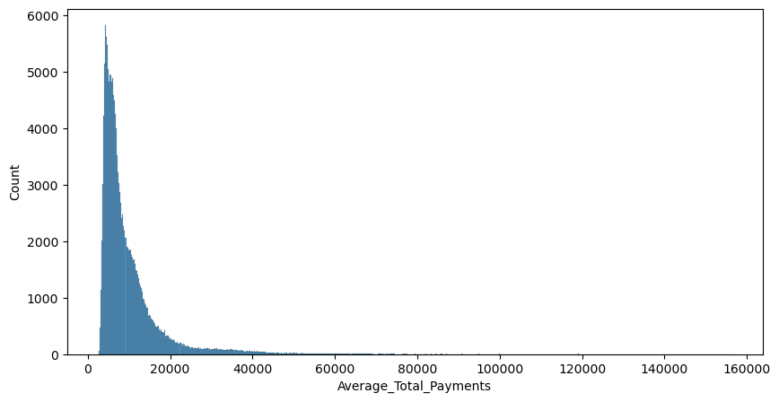

```python
plt.figure(figsize=(10,5)) # Plot a graph with reasonable size.
sns.histplot(data['Average_Total_Payments'])
plt.show()
```

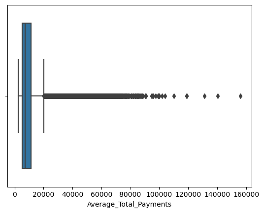

```python
sns.boxplot(x = 'Average_Total_Payments', data = data)
```

### Section 2.2: Count by State

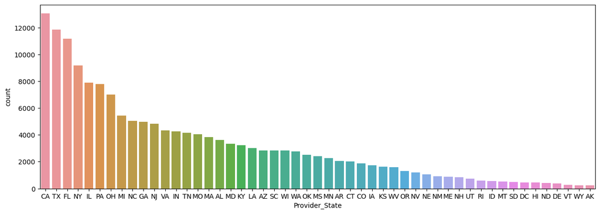

```python
# data['Provider_State'].value_counts()
plt.figure(figsize=(15,5))
sns.countplot(x='Provider_State',data=data,order=data['Provider_State'].value_counts().index)
plt.rcParams["axes.labelsize"] = 20
```

##### From this graph, the California, Texa, and Florid have the highest number of hospital divisions.

### Section 2.3: Count of top 20 cities

```python
data['Provider_Name'].value_counts()
```

```
Provider_Name
GOOD SAMARITAN HOSPITAL                  633
ST JOSEPH MEDICAL CENTER                 427
MERCY MEDICAL CENTER                     357
MERCY HOSPITAL                           347
ST JOSEPH HOSPITAL                       343
                                        ...
J PAUL JONES HOSPITAL                      1
GREATER BATON ROUGE SURGICAL HOSPITAL      1
FAIRWAY MEDICAL CENTER                     1
MONROE SURGICAL HOSPITAL                   1
EAGLEVILLE HOSPITAL                        1
Name: count, Length: 3201, dtype: int64
```

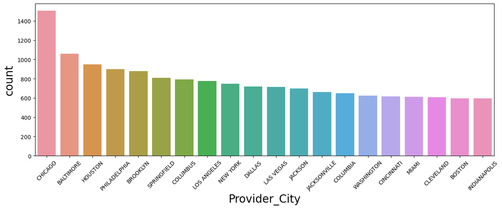

```python
plt.figure(figsize=(15,5))
txt = data['Provider_City'].value_counts()[:20].index

chart = sns.countplot(
    x='Provider_City' ,data=data , order=txt
)

_ = chart.set_xticklabels(chart.get_xticklabels(), rotation=45)
plt.rcParams["axes.labelsize"] = 10
```

## Section 3: Feature Engineering

### Section 3.1: Create the benchmark table - State & DRG average total payment

#### Feature 1: Ratio of a Hospital's "Average_Total_Payment" to the State Average_Total_Payment By DRG

#### Feature 2: Ratio of the "Average_Total_Payment" in a City to the State Average_Total_Payment By DRG

#### Feature 3: Ratio of a Provider's "Average_Total_Payment" to State Average_Total_Payment By DRG

```python
#这段benchmark是计算了每个州（Provider_State）和每个DRG类别内的平均支付金额（Avg_Payment_ByStateDRG）。
#可以把每家医院的支付金额与它所在的州和DRG类别的平均值来进行对比，找出是否有医院明显超出平均值。
#Here is the benchmark
benchmark_by_stateDRG = data.groupby(['Provider_State','DRG'])['Average_Total_Payments'].mean().reset_index()
benchmark_by_stateDRG.columns = ['Provider_State','DRG','Avg_Payment_ByStateDRG']
benchmark_by_stateDRG.head()
```

|  | Provider_State | DRG | Avg_Payment_ByStateDRG |
| --- | --- | --- | --- |
| 0 | AK | 039 - EXTRACRANIAL PROCEDURES W/O CC/MCC | 8401.950000 |
| 1 | AK | 057 - DEGENERATIVE NERVOUS SYSTEM DISORDERS W/... | 8799.000000 |
| 2 | AK | 064 - INTRACRANIAL HEMORRHAGE OR CEREBRAL INFA... | 21608.010000 |
| 3 | AK | 065 - INTRACRANIAL HEMORRHAGE OR CEREBRAL INFA... | 12555.548333 |
| 4 | AK | 066 - INTRACRANIAL HEMORRHAGE OR CEREBRAL INFA... | 9275.867500 |

```python
# Merge this benchmark with dataset
F123 = pd.merge(data, benchmark_by_stateDRG, how='left', on=['Provider_State', 'DRG'])
F123
```

|  | DRG | Provider_Id | Provider_Name | Provider_StreetAddress | Provider_City | Provider_State | Provider_Zipcode | Hospital_referral_region_desp | Total_Discharges | Average_Total_Payments | Average_Medicare_Payment | Avg_Payment_ByStateDRG |
| --- | --- | --- | --- | --- | --- | --- | --- | --- | --- | --- | --- | --- |
| 0 | 039 - EXTRACRANIAL PROCEDURES W/O CC/MCC | 10001 | SOUTHEAST ALABAMA MEDICAL CENTER | 1108 ROSS CLARK CIRCLE | DOTHAN | AL | 36301 | AL - Dothan | 91 | 5777.24 | 4763.73 | 5743.611739 |
| 1 | 039 - EXTRACRANIAL PROCEDURES W/O CC/MCC | 10005 | MARSHALL MEDICAL CENTER SOUTH | 2505 U S HIGHWAY 431 NORTH | BOAZ | AL | 35957 | AL - Birmingham | 14 | 5787.57 | 4976.71 | 5743.611739 |
| 2 | 039 - EXTRACRANIAL PROCEDURES W/O CC/MCC | 10006 | ELIZA COFFEE MEMORIAL HOSPITAL | 205 MARENGO STREET | FLORENCE | AL | 35631 | AL - Birmingham | 24 | 5434.95 | 4453.79 | 5743.611739 |
| 3 | 039 - EXTRACRANIAL PROCEDURES W/O CC/MCC | 10011 | ST VINCENT'S EAST | 50 MEDICAL PARK EAST DRIVE | BIRMINGHAM | AL | 35235 | AL - Birmingham | 25 | 5417.56 | 4129.16 | 5743.611739 |
| 4 | 039 - EXTRACRANIAL PROCEDURES W/O CC/MCC | 10016 | SHELBY BAPTIST MEDICAL CENTER | 1000 FIRST STREET NORTH | ALABASTER | AL | 35007 | AL - Birmingham | 18 | 5658.33 | 4851.44 | 5743.611739 |
| ... | ... | ... | ... | ... | ... | ... | ... | ... | ... | ... | ... | ... |
| 163060 | 948 - SIGNS & SYMPTOMS W/O MCC | 670041 | SETON MEDICAL CENTER WILLIAMSON | 201 SETON PARKWAY | ROUND ROCK | TX | 78664 | TX - Austin | 23 | 3806.86 | 3071.39 | 4631.003966 |
| 163061 | 948 - SIGNS & SYMPTOMS W/O MCC | 670055 | METHODIST STONE OAK HOSPITAL | 1139 E SONTERRA BLVD | SAN ANTONIO | TX | 78258 | TX - San Antonio | 11 | 4027.36 | 2649.72 | 4631.003966 |
| 163062 | 948 - SIGNS & SYMPTOMS W/O MCC | 670056 | SETON MEDICAL CENTER HAYS | 6001 KYLE PKWY | KYLE | TX | 78640 | TX - Austin | 19 | 5704.36 | 4058.36 | 4631.003966 |
| 163063 | 948 - SIGNS & SYMPTOMS W/O MCC | 670060 | TEXAS REGIONAL MEDICAL CENTER AT SUNNYVALE | 231 SOUTH COLLINS ROAD | SUNNYVALE | TX | 75182 | TX - Dallas | 11 | 7663.09 | 6848.54 | 4631.003966 |
| 163064 | 948 - SIGNS & SYMPTOMS W/O MCC | 670068 | TEXAS HEALTH PRESBYTERIAN HOSPITAL FLOWER MOUND | 4400 LONG PRAIRIE ROAD | FLOWER MOUND | TX | 75028 | TX - Dallas | 12 | 3539.75 | 2887.41 | 4631.003966 |

163065 rows × 12 columns

#### Feature 1: Ratio of a Hospital's "Average_Total_Payment" to the State Average_Total_Payment By DRG

##### The goal of feature1 is to identify and detect anomalies in hospital biling practices by comparing the average total payment of an individual hospital to the state average for the same Diagnosis Related Group(DRG). This feature helps to highlight hospitals that might be in overbilling or underbilling.

```python
#Create the Feature 1：Ratio of a Hospital's "Average_Total_Payment" to the State Average_Total_Payment By DRG
F123['Hospital_Average_Total_Payments_bySTDRG'] = F123['Average_Total_Payments'] / F123['Avg_Payment_ByStateDRG'].replace(0, np.nan)
```

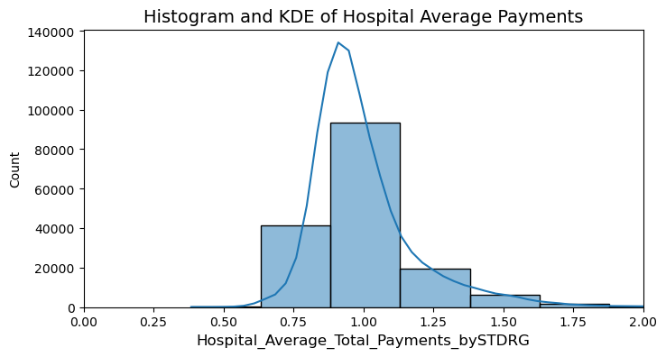

```python
plt.figure(figsize=(8, 4))
sns.histplot(data=F123, x='Hospital_Average_Total_Payments_bySTDRG', kde=True, bins=30)
plt.xlim(0, 2)
plt.title("Histogram and KDE of Hospital Average Payments", fontsize=14)
plt.xlabel("Hospital_Average_Total_Payments_bySTDRG", fontsize=12)

plt.show()
```

##### Most hospitals in the dataset have a ratio between 0.5 and 1.5, which means their payments are relatively close to the state average for thir DRG category. And the KDE peak here around 1, showing that the majority of hospitals are charging approximately the same as the state average. And the plot is right-skewed, meaning that while most hospitals charge near the state average, there are a few hospitals that charge much more. The long tail on the right suggests there existing outliers.

#### Feature 2: Ratio of the "Average_Total_Payment" in a City to the State Average_Total_Payment By DRG

##### The goal of create the feature2 is to compare the average total payment across all hospitals within a city to the state average for the same DRG. This feature helps to identify regional billing trends and detect potential anomalies at the city level, revealing cities where healthcare costs might be unusually high or low compared to the statebench mark.

```python
city_avg_payment = F123.groupby(['Provider_City', 'DRG'])['Average_Total_Payments'].mean().reset_index()
city_avg_payment.columns = ['Provider_City', 'DRG', 'City_Avg_Payment']

# Merge the city average payment with the main dataset
F123 = pd.merge(F123, city_avg_payment, on=['Provider_City', 'DRG'], how='left')

# Calculate Feature 2: Ratio of City Average Payment to State Average Payment by DRG
F123['City_to_State_Payment_Ratio'] = F123['City_Avg_Payment'] / F123['Avg_Payment_ByStateDRG']
```

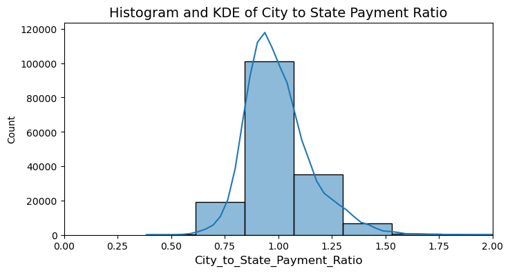

```python
# Distribution of City Average Payments
plt.figure(figsize=(8, 4))
sns.histplot(data=F123, x='City_to_State_Payment_Ratio', kde=True, bins=30)
plt.xlim(0, 2)
plt.title("Histogram and KDE of City to State Payment Ratio", fontsize=14)
plt.xlabel("City_to_State_Payment_Ratio", fontsize=12)

plt.show()
```

##### Most cities have a ratio close to 1, cities are billing Medicare payments similar to the state average for the same DRG. Cities with ratios lower than 1 are charging less than the state average. This could mean lower costs or more efficient billing practices. Most data points cluster here are around 0.75 to 1.25, the range shows small deviations around the state average. And a peak is close to 1, most cities align well with the state-level billing.

#### Feature 3: Ratio of a Provider's "Average_Total_Payment" to State Average_Total_Payment By DRG

##### The goal to create this feature3 is to evaluate and compare the average total payment of individual providers to the state average for the same DRG. It will detect outlier providers whose billing practices significantly deviate from the normal, identifying potential cases of overbilling, underbilling.

```python
provider_avg_payment = data.groupby(['Provider_Id', 'DRG'])['Average_Total_Payments'].mean().reset_index()
provider_avg_payment.columns = ['Provider_Id', 'DRG', 'Provider_Avg_Payment']

# Merge the provider average payment with the main dataset
F123 = pd.merge(F123, provider_avg_payment, on=['Provider_Id', 'DRG'], how='left')

# Calculate Feature 3: Ratio of Provider Average Payment to State Average Payment by DRG
F123['Provider_to_State_Payment_Ratio'] = F123['Provider_Avg_Payment'] / F123['Avg_Payment_ByStateDRG']
```

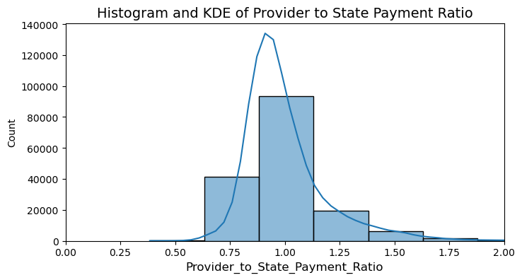

```python
# Plot the distribution of the new feature
plt.figure(figsize=(8, 4))
sns.histplot(data=F123, x='Provider_to_State_Payment_Ratio', kde=True, bins=30)
plt.xlim(0, 2)
plt.title("Histogram and KDE of Provider to State Payment Ratio", fontsize=14)
plt.xlabel("Provider_to_State_Payment_Ratio", fontsize=12)

plt.show()
```

##### Most providers have a ratio close to 1, this suggests that the majority of providers charge medicare payments that are consistent with the state average for the same DRG, indicating standardized billing pratices. And providers with ratio above 1 are charging more than the state average, which could indicate higher service costs or potential overbilling.

### Section 3.2: Create the benchmark table - State & DRG total discharge

#### Feature 4: Ratio of a Hospital's "Total Discharges" to the State Total Discharges By DRG

#### Feature 5: Ratio of the "Total Discharges" in a City to the State Total Discharges By DRG

#### Feature 6: Ratio of a Provider's "Total Discharges" to the State Total Discharges By DRG

```python
# Create benchmark for State Total_Discharges by DRG
benchmark_discharges_by_stateDRG = data.groupby(['Provider_State', 'DRG'])['Total_Discharges'].sum().reset_index()
benchmark_discharges_by_stateDRG.columns = ['Provider_State', 'DRG', 'Total_Discharges_ByStateDRG']

# Merge
F345 = pd.merge(data, benchmark_discharges_by_stateDRG, how='left', on=['Provider_State', 'DRG'])

print("First few rows of the F345 dataset:")
F345.head()
```

```
First few rows of the F345 dataset:
```

|  | DRG | Provider_Id | Provider_Name | Provider_StreetAddress | Provider_City | Provider_State | Provider_Zipcode | Hospital_referral_region_desp | Total_Discharges | Average_Total_Payments | Average_Medicare_Payment | Total_Discharges_ByStateDRG |
| --- | --- | --- | --- | --- | --- | --- | --- | --- | --- | --- | --- | --- |
| 0 | 039 - EXTRACRANIAL PROCEDURES W/O CC/MCC | 10001 | SOUTHEAST ALABAMA MEDICAL CENTER | 1108 ROSS CLARK CIRCLE | DOTHAN | AL | 36301 | AL - Dothan | 91 | 5777.24 | 4763.73 | 879 |
| 1 | 039 - EXTRACRANIAL PROCEDURES W/O CC/MCC | 10005 | MARSHALL MEDICAL CENTER SOUTH | 2505 U S HIGHWAY 431 NORTH | BOAZ | AL | 35957 | AL - Birmingham | 14 | 5787.57 | 4976.71 | 879 |
| 2 | 039 - EXTRACRANIAL PROCEDURES W/O CC/MCC | 10006 | ELIZA COFFEE MEMORIAL HOSPITAL | 205 MARENGO STREET | FLORENCE | AL | 35631 | AL - Birmingham | 24 | 5434.95 | 4453.79 | 879 |
| 3 | 039 - EXTRACRANIAL PROCEDURES W/O CC/MCC | 10011 | ST VINCENT'S EAST | 50 MEDICAL PARK EAST DRIVE | BIRMINGHAM | AL | 35235 | AL - Birmingham | 25 | 5417.56 | 4129.16 | 879 |
| 4 | 039 - EXTRACRANIAL PROCEDURES W/O CC/MCC | 10016 | SHELBY BAPTIST MEDICAL CENTER | 1000 FIRST STREET NORTH | ALABASTER | AL | 35007 | AL - Birmingham | 18 | 5658.33 | 4851.44 | 879 |

#### Feature 4: Ratio of a Hospital's "Total Discharges" to the State Total Discharges By DRG

##### The goal to create this feature4 is to compare the total number of discharges from a specific hospital to the state-level total discharge for the same DRP. This feature to detect anomalies in how hospitals handle patient volumnes for particular medical procedures, allowing for insights into hospital capacity, efficiency, and potential overuse or underuse of resources.

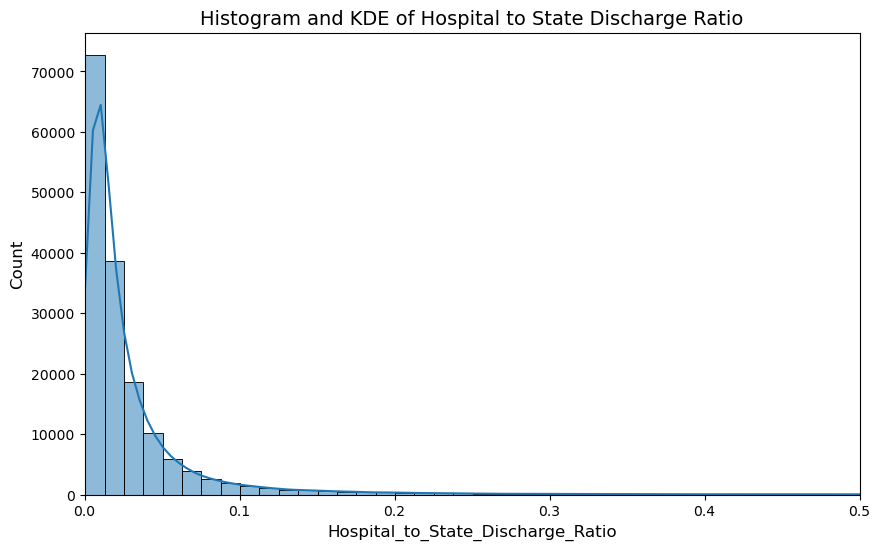

```python
# Calculate Feature 4: Ratio of a hospital's discharge to the state discharge by DRG
F345['Hospital_to_State_Discharge_Ratio'] = F345['Total_Discharges'] / F345['Total_Discharges_ByStateDRG']

# Plot the distribution of the new feature
plt.figure(figsize=(10, 6))
sns.histplot(data=F345, x='Hospital_to_State_Discharge_Ratio', kde=True, bins=80)
plt.xlim(0, 0.5)
plt.title("Histogram and KDE of Hospital to State Discharge Ratio", fontsize=14)
plt.xlabel("Hospital_to_State_Discharge_Ratio", fontsize=12)
plt.ylabel("Count", fontsize=12)

plt.show()
```

##### Most hospitals have a very low ratio inficates that the majority of hospitals handle a small fraction of the state's total discharges for specific DRGs. The graph is heavily skewed to the right, showing that a few hospitals have higher ratios, meaning they manage more discharges than most others. Hospitals with ratios significantly higher than the rest which are in the long tail of the graph could be outliers indicating high patient volumes or potential overuse of service.

#### Feature 5: Ratio of the "Total Discharges" in a City to the State Total Discharges By DRG

##### This feature 5 is compare the total number of discharges from all hospitals within a city to the state-wide total discharges for the same DRG. The goal for this feature is to anlayze regional trends in patient volume, identify cities with unusual high or low service utilization, and provide insights into resource distribution and healthcare accessbility.

```python
city_total_discharges = F345.groupby(['Provider_City', 'DRG'])['Total_Discharges'].sum().reset_index()
city_total_discharges.columns = ['Provider_City', 'DRG', 'City_Total_Discharges']

# Merge the city total discharges with the main dataset
F345 = pd.merge(F345, city_total_discharges, on=['Provider_City', 'DRG'], how='left')

# Calculate Feature 5
F345['City_to_State_Discharge_Ratio'] = F345['City_Total_Discharges'] / F345['Total_Discharges_ByStateDRG']
```

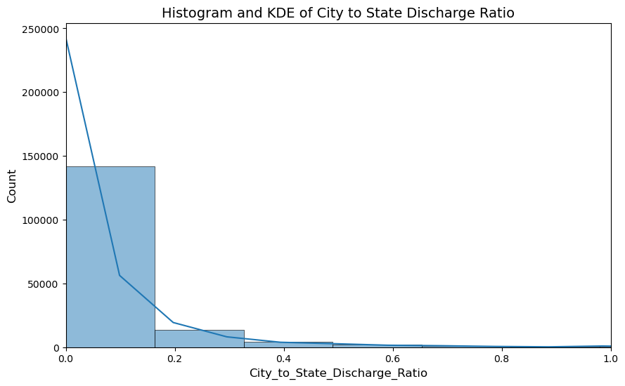

```python
# Plot the distribution of the new feature
plt.figure(figsize=(10, 6))
sns.histplot(data=F345, x='City_to_State_Discharge_Ratio', kde=True, bins=120)
plt.xlim(0, 1)
plt.title("Histogram and KDE of City to State Discharge Ratio", fontsize=14)
plt.xlabel("City_to_State_Discharge_Ratio", fontsize=12)
plt.ylabel("Count", fontsize=12)

plt.show()
```

##### The graph is right-skewed showing that a few cities have higher ratios, they handle more discharges than others. And cities with ratios which are significantly higher than the rest, which are in long tail are outliers, suggesting that they may have specialized healthcare centers or higher demand for certain medical service, maybe requiring further analysis to understand reason.

#### Feature 6: Ratio of a Provider's "Total Discharges" to the State Total Discharges By DRG

##### The feature 6 compares the total number of discharges handled by an individual provider to the state-wide total discharge for the same DRG. The objective is to identify providers who play a significant role in handling specific types of medical case, to detect any anomalies in service utlization that could indicate overuse, underuse, or inefficiencies.

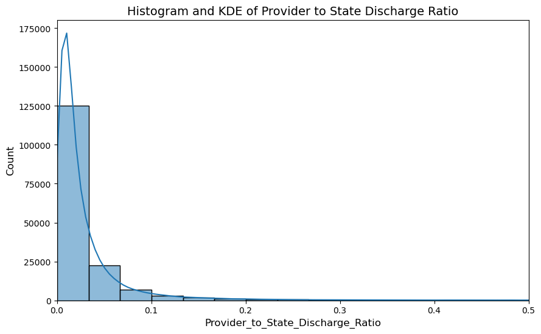

```python
# Calculate Feature 6: Ratio of Provider's Discharge to State Discharge by DRG
F345['Provider_to_State_Discharge_Ratio'] = F345['Total_Discharges'] / F345['Total_Discharges_ByStateDRG']

# Plot the distribution of the new feature
plt.figure(figsize=(10, 6))
sns.histplot(data=F345, x='Provider_to_State_Discharge_Ratio', kde=True, bins=30)
plt.xlim(0, 0.5)
plt.title("Histogram and KDE of Provider to State Discharge Ratio", fontsize=14)
plt.xlabel("Provider_to_State_Discharge_Ratio", fontsize=12)
plt.ylabel("Count", fontsize=12)

plt.show()
```

##### This graph is also right-skewed, with a few providers showing higher ratios, meaning they handle more discharges compared to others, and most providers contribute a small portion of the state's total discharges for specific DRGs. Providers with signifcantly higher ratios are outliers.

### Section 3.3: Create the benchmark table - State & DRG Average_Medicare_Payment

#### Feature 7: Ratio of a Hospital's "Average Medicare Payment" to the State Average Medicare Payment By DRG

#### Feature 8: Ratio of the "Average Medicare Payment" in a City to the State Average Medicare Payment By DRG

#### Feature 9: Ratio of a Provider's "Average Medicare Payment" to the State Average Medicare Payment By DRG

```python
# Create benchmark for State Average Medical Payment by DRG
benchmark_medical_payment_by_stateDRG = data.groupby(['Provider_State', 'DRG'])['Average_Medicare_Payment'].mean().reset_index()
benchmark_medical_payment_by_stateDRG.columns = ['Provider_State', 'DRG', 'Avg_Medicare_Payment_ByStateDRG']

print("New benchmark - State Average Medicare Payment by DRG:")
benchmark_medical_payment_by_stateDRG.head()
```

```
New benchmark - State Average Medicare Payment by DRG:
```

|  | Provider_State | DRG | Avg_Medicare_Payment_ByStateDRG |
| --- | --- | --- | --- |
| 0 | AK | 039 - EXTRACRANIAL PROCEDURES W/O CC/MCC | 6413.780000 |
| 1 | AK | 057 - DEGENERATIVE NERVOUS SYSTEM DISORDERS W/... | 8081.540000 |
| 2 | AK | 064 - INTRACRANIAL HEMORRHAGE OR CEREBRAL INFA... | 20555.255000 |
| 3 | AK | 065 - INTRACRANIAL HEMORRHAGE OR CEREBRAL INFA... | 11140.963333 |
| 4 | AK | 066 - INTRACRANIAL HEMORRHAGE OR CEREBRAL INFA... | 8258.427500 |

```python
# Merge this new benchmark with the original dataset
F789 = pd.merge(data, benchmark_medical_payment_by_stateDRG, how='left', on=['Provider_State', 'DRG'])
F789.head()
```

|  | DRG | Provider_Id | Provider_Name | Provider_StreetAddress | Provider_City | Provider_State | Provider_Zipcode | Hospital_referral_region_desp | Total_Discharges | Average_Total_Payments | Average_Medicare_Payment | Avg_Medicare_Payment_ByStateDRG |
| --- | --- | --- | --- | --- | --- | --- | --- | --- | --- | --- | --- | --- |
| 0 | 039 - EXTRACRANIAL PROCEDURES W/O CC/MCC | 10001 | SOUTHEAST ALABAMA MEDICAL CENTER | 1108 ROSS CLARK CIRCLE | DOTHAN | AL | 36301 | AL - Dothan | 91 | 5777.24 | 4763.73 | 4599.593043 |
| 1 | 039 - EXTRACRANIAL PROCEDURES W/O CC/MCC | 10005 | MARSHALL MEDICAL CENTER SOUTH | 2505 U S HIGHWAY 431 NORTH | BOAZ | AL | 35957 | AL - Birmingham | 14 | 5787.57 | 4976.71 | 4599.593043 |
| 2 | 039 - EXTRACRANIAL PROCEDURES W/O CC/MCC | 10006 | ELIZA COFFEE MEMORIAL HOSPITAL | 205 MARENGO STREET | FLORENCE | AL | 35631 | AL - Birmingham | 24 | 5434.95 | 4453.79 | 4599.593043 |
| 3 | 039 - EXTRACRANIAL PROCEDURES W/O CC/MCC | 10011 | ST VINCENT'S EAST | 50 MEDICAL PARK EAST DRIVE | BIRMINGHAM | AL | 35235 | AL - Birmingham | 25 | 5417.56 | 4129.16 | 4599.593043 |
| 4 | 039 - EXTRACRANIAL PROCEDURES W/O CC/MCC | 10016 | SHELBY BAPTIST MEDICAL CENTER | 1000 FIRST STREET NORTH | ALABASTER | AL | 35007 | AL - Birmingham | 18 | 5658.33 | 4851.44 | 4599.593043 |

#### Feature 7: Ratio of a Hospital's "Average Medicare Payment" to the State Average Medicare Payment By DRG

##### The feature 7 compares the average medicare payment charged by a specific hospital to the state-wide average medicare payment for the smae DRG. The purpose of this feature is to identify variations in Medicare billing practices across hospitals, detect anomalies in pricing.

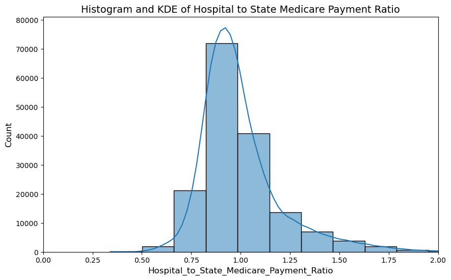

```python
# Calculate Feature 7
F789['Hospital_to_State_Medicare_Payment_Ratio'] = F789['Average_Medicare_Payment'] / F789['Avg_Medicare_Payment_ByStateDRG']

# Plot the distribution
plt.figure(figsize=(10, 6))
sns.histplot(data=F789, x='Hospital_to_State_Medicare_Payment_Ratio', kde=True, bins=30)
plt.xlim(0, 2)
plt.title("Histogram and KDE of Hospital to State Medicare Payment Ratio", fontsize=14)
plt.xlabel("Hospital_to_State_Medicare_Payment_Ratio", fontsize=12)
plt.ylabel("Count", fontsize=12)

plt.show()
```

##### Most hospitals have a ratio around 1, indicating that the majority of hospitals charge medicare payment close to the state average. And the graph shows a little right-skewed here, meaning there are hospitals with higher ratios charge more than the state average. For hospitals with ratios significantly greater than 1 are outliers, suggesting higher medicare payment compared to the state average, which may indicate potential overbilling or inefficiencies.

#### Feature 8: Ratio of the "Average Medicare Payment" in a City to the State Average Medicare Payment By DRG

##### The feature 8 compares the average medicare payment charged across all hospitals within a specific city to the state-wide average medicare payment for the smae DRG. The purpose for this feature is to identify regional variations in medicare billing, understand city-level pricing trends, and help ensure fair and consistent Medicare charges across different cities within a state.

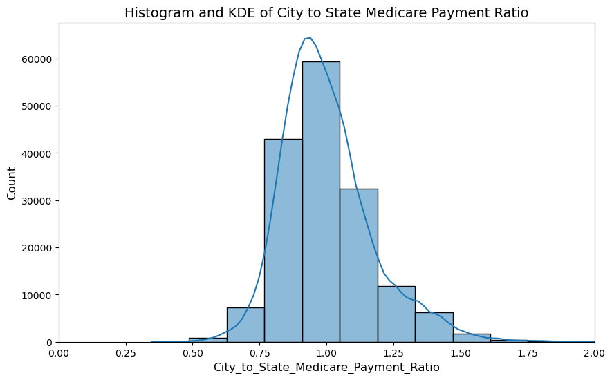

```python
# Calculate the average Medicare payment by city and DRG
city_avg_medicare_payment = F789.groupby(['Provider_City', 'DRG'])['Average_Medicare_Payment'].mean().reset_index()
city_avg_medicare_payment.columns = ['Provider_City', 'DRG', 'City_Avg_Medicare_Payment']

# Merge
F789 = pd.merge(F789, city_avg_medicare_payment, on=['Provider_City', 'DRG'], how='left')

# Calculate Feature 8
F789['City_to_State_Medicare_Payment_Ratio'] = F789['City_Avg_Medicare_Payment'] / F789['Avg_Medicare_Payment_ByStateDRG']

# Plot the distribution
plt.figure(figsize=(10, 6))
sns.histplot(data=F789, x='City_to_State_Medicare_Payment_Ratio', kde=True, bins=30)
plt.xlim(0, 2)
plt.title("Histogram and KDE of City to State Medicare Payment Ratio", fontsize=14)
plt.xlabel("City_to_State_Medicare_Payment_Ratio", fontsize=12)
plt.ylabel("Count", fontsize=12)

plt.show()
```

##### Most cities have a ratio around 1, suggesting that the majority of cities charge Medicare payments close to the state average, indicating consistenting billing practices across cities. The graph is almost symmetrical, with a peak around 1, meaning most cities' payments are near the state average. There are fewer cities on the right, indicating some cities charge higher than the average, Cities with ratios significantly greater than 1 are outliers that may indicate higher billing or overcharging compared the state norm.

#### Feature 9: Ratio of a Provider's "Average Medicare Payment" to the State Average Medicare Payment By DRG

##### The feature 9 compares the average medicare payment charged by an individual providers to the state-wide averafe medicare payment for the same DRG. The purpose of this feature is to identify outlier providers who deviate from typical billing practices, detecting potential overbilling, underbilling and inefficiencies at the provider level.

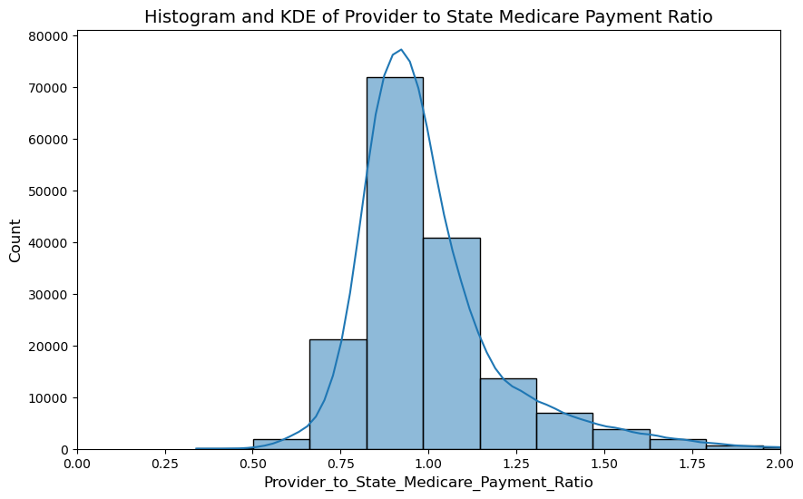

```python
# Calculate Feature 9
F789['Provider_to_State_Medicare_Payment_Ratio'] = F789['Average_Medicare_Payment'] / F789['Avg_Medicare_Payment_ByStateDRG']

# Plot the distribution
plt.figure(figsize=(10, 6))
sns.histplot(data=F789, x='Provider_to_State_Medicare_Payment_Ratio', kde=True, bins=30)
plt.xlim(0, 2)
plt.title("Histogram and KDE of Provider to State Medicare Payment Ratio", fontsize=14)
plt.xlabel("Provider_to_State_Medicare_Payment_Ratio", fontsize=12)
plt.ylabel("Count", fontsize=12)

plt.show()
```

##### Most providers have a ratio around 1, indicating that the majority of providers charge Medicare payments close to the state average. And the distribution here is slightly right-skewed, there are some providers charging higher than the average. Providers with ratios significantly greater than 1 are outliers, that may indicate overbillinng or higher costs.

### Section 3.4: Create the benchmark table - State & DRG Average Total Payment per discharge

#### Feature 10: Ratio of Hospital's Average Payment to State Average Total Payment per Discharge by DRG

#### Feature 11: Ratio of Average Payment by City to State Average Total Payment per Discharge by DRG

#### Feature 12: Ratio of Provider's Average Payment per Discharge to State Average Total Payment per Discharge by DRG

```python
# Create benchmark for State Average Total Payment per Discharge by DRG
benchmark_payment_per_discharge_by_stateDRG = data.groupby(['Provider_State', 'DRG']).agg({
    'Average_Total_Payments': 'sum',
    'Total_Discharges': 'sum'
}).reset_index()

benchmark_payment_per_discharge_by_stateDRG['Avg_Payment_Per_Discharge_ByStateDRG'] = (
    benchmark_payment_per_discharge_by_stateDRG['Average_Total_Payments'] /
    benchmark_payment_per_discharge_by_stateDRG['Total_Discharges']
)

benchmark_payment_per_discharge_by_stateDRG = benchmark_payment_per_discharge_by_stateDRG[['Provider_State', 'DRG', 'Avg_Payment_Per_Discharge_ByStateDRG']]
benchmark_payment_per_discharge_by_stateDRG.head()

# Merge this new benchmark with the original data dataset and name it F101112
F101112 = pd.merge(data, benchmark_payment_per_discharge_by_stateDRG, how='left', on=['Provider_State', 'DRG'])
F101112.head()
```

|  | DRG | Provider_Id | Provider_Name | Provider_StreetAddress | Provider_City | Provider_State | Provider_Zipcode | Hospital_referral_region_desp | Total_Discharges | Average_Total_Payments | Average_Medicare_Payment | Avg_Payment_Per_Discharge_ByStateDRG |
| --- | --- | --- | --- | --- | --- | --- | --- | --- | --- | --- | --- | --- |
| 0 | 039 - EXTRACRANIAL PROCEDURES W/O CC/MCC | 10001 | SOUTHEAST ALABAMA MEDICAL CENTER | 1108 ROSS CLARK CIRCLE | DOTHAN | AL | 36301 | AL - Dothan | 91 | 5777.24 | 4763.73 | 150.287907 |
| 1 | 039 - EXTRACRANIAL PROCEDURES W/O CC/MCC | 10005 | MARSHALL MEDICAL CENTER SOUTH | 2505 U S HIGHWAY 431 NORTH | BOAZ | AL | 35957 | AL - Birmingham | 14 | 5787.57 | 4976.71 | 150.287907 |
| 2 | 039 - EXTRACRANIAL PROCEDURES W/O CC/MCC | 10006 | ELIZA COFFEE MEMORIAL HOSPITAL | 205 MARENGO STREET | FLORENCE | AL | 35631 | AL - Birmingham | 24 | 5434.95 | 4453.79 | 150.287907 |
| 3 | 039 - EXTRACRANIAL PROCEDURES W/O CC/MCC | 10011 | ST VINCENT'S EAST | 50 MEDICAL PARK EAST DRIVE | BIRMINGHAM | AL | 35235 | AL - Birmingham | 25 | 5417.56 | 4129.16 | 150.287907 |
| 4 | 039 - EXTRACRANIAL PROCEDURES W/O CC/MCC | 10016 | SHELBY BAPTIST MEDICAL CENTER | 1000 FIRST STREET NORTH | ALABASTER | AL | 35007 | AL - Birmingham | 18 | 5658.33 | 4851.44 | 150.287907 |

#### Feature 10: Ratio of Hospital's Average Payment to State Average Total Payment per Discharge by DRG

##### Feature 10 is to compare the average payment per discharge for a specific hospital to the state-wide average payment per discharge for the same DRG. This helps to identify variations in billing practices and potential cost efficiencies or inefficiencies.

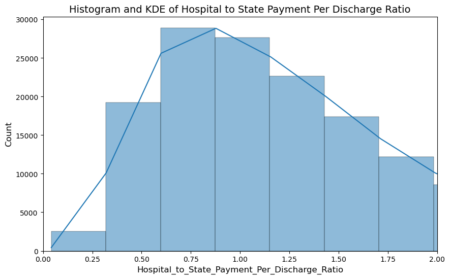

```python
# hospital's average payment per discharge
F101112['Hospital_Avg_Payment_Per_Discharge'] = F101112['Average_Total_Payments'] / F101112['Total_Discharges']

# Calculate Feature 10
F101112['Hospital_to_State_Payment_Per_Discharge_Ratio'] = F101112['Hospital_Avg_Payment_Per_Discharge'] / F101112['Avg_Payment_Per_Discharge_ByStateDRG']

# Plot the distribution of the new feature
plt.figure(figsize=(10, 6))
sns.histplot(data=F101112, x='Hospital_to_State_Payment_Per_Discharge_Ratio', kde=True, bins=200)
plt.xlim(0, 2)
plt.title("Histogram and KDE of Hospital to State Payment Per Discharge Ratio", fontsize=14)
plt.xlabel("Hospital_to_State_Payment_Per_Discharge_Ratio", fontsize=12)
plt.ylabel("Count", fontsize=12)

plt.show()
```

#### Feature 11: Ratio of Average Payment by City to State Average Total Payment per Discharge by DRG

##### The feature 11 indicate to compare the average payment per discharge at the city level to the state-wide average for the same DRG. This helps in identifying variations in healthcare costs across different cities.

```python
# Calculate the average payment per discharge by city and DRG
city_avg_payment_per_discharge = F101112.groupby(['Provider_City', 'DRG']).agg({
    'Average_Total_Payments': 'sum',
    'Total_Discharges': 'sum'
}).reset_index()

city_avg_payment_per_discharge['City_Avg_Payment_Per_Discharge'] = (
    city_avg_payment_per_discharge['Average_Total_Payments'] /
    city_avg_payment_per_discharge['Total_Discharges']
)
# Merge the city average payment per discharge with the origin dataset
F101112 = pd.merge(F101112, city_avg_payment_per_discharge[['Provider_City', 'DRG', 'City_Avg_Payment_Per_Discharge']],
                   on=['Provider_City', 'DRG'], how='left')
```

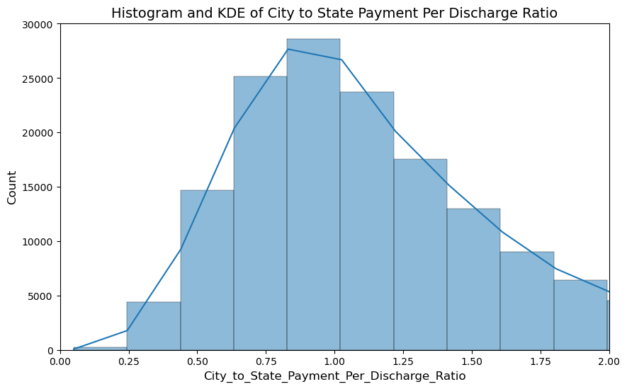

```python
# Calculate Feature 11
F101112['City_to_State_Payment_Per_Discharge_Ratio'] = F101112['City_Avg_Payment_Per_Discharge'] / F101112['Avg_Payment_Per_Discharge_ByStateDRG']

# Plot the distribution
plt.figure(figsize=(10, 6))
sns.histplot(data=F101112, x='City_to_State_Payment_Per_Discharge_Ratio', kde=True, bins=200)
plt.xlim(0, 2)
plt.title("Histogram and KDE of City to State Payment Per Discharge Ratio", fontsize=14)
plt.xlabel("City_to_State_Payment_Per_Discharge_Ratio", fontsize=12)
plt.ylabel("Count", fontsize=12)

plt.show()
```

##### The distribution is centered around 1, indicateing that most cities have average payments per discharge close to the state average. Here, outliers can be identified as values far below or above the peak which is 1.

#### Feature 12: Ratio of Provider's Average Payment per Discharge to State Average Total Payment per Discharge by DRG

##### This feature identifies potential discrepancies or inefficiencies at the provider level.

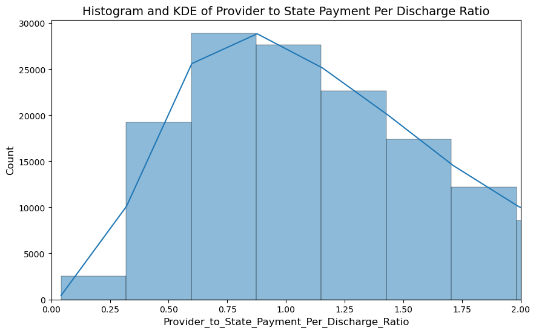

```python
# Calculate Feature 12: Ratio of Provider's Average Payment per Discharge to State Average Payment per Discharge by DRG
F101112['Provider_Avg_Payment_Per_Discharge'] = F101112['Average_Total_Payments'] / F101112['Total_Discharges']
F101112['Provider_to_State_Payment_Per_Discharge_Ratio'] = F101112['Provider_Avg_Payment_Per_Discharge'] / F101112['Avg_Payment_Per_Discharge_ByStateDRG']

# Plot the distribution of the new feature
plt.figure(figsize=(10, 6))
sns.histplot(data=F101112, x='Provider_to_State_Payment_Per_Discharge_Ratio', kde=True, bins=200)

# Set x-axis limits (adjust as needed based on your data)
plt.xlim(0, 2)  # You might need to adjust this based on your data distribution

# Add labels and title
plt.title("Histogram and KDE of Provider to State Payment Per Discharge Ratio", fontsize=14)
plt.xlabel("Provider_to_State_Payment_Per_Discharge_Ratio", fontsize=12)
plt.ylabel("Count", fontsize=12)

plt.show()
```

##### Most values are clustered around1, indicating that many providers' payments per discharge are close to that state average. Outliers can be detected by looking for extreme values far from 1, especially those significantly higher like above 2.

### Section 3.5: Create the benchmark table - State & DRG Average Medicare per discharge

#### Feature 13: Ratio of Hospital's Average Medicare Payment per discharge to State Average Payment per discharge by DRG

#### Feature 14: Ratio of Average Medicare Payment by City per discharge to State Average Payment per discharge on DRG

#### Feature 15: Ratio of Provider's Average Medicare Payment per discharge to State Average Payment per discharge by DRG

```python
# Create benchmark for State Average Medicare Payment per Discharge by DRG
benchmark_medicare_per_discharge_by_stateDRG = data.groupby(['Provider_State', 'DRG']).agg({
    'Average_Medicare_Payment': 'sum',
    'Total_Discharges': 'sum'
}).reset_index()

benchmark_medicare_per_discharge_by_stateDRG['Avg_Medicare_Per_Discharge_ByStateDRG'] = (
    benchmark_medicare_per_discharge_by_stateDRG['Average_Medicare_Payment'] /
    benchmark_medicare_per_discharge_by_stateDRG['Total_Discharges']
)

benchmark_medicare_per_discharge_by_stateDRG = benchmark_medicare_per_discharge_by_stateDRG[['Provider_State', 'DRG', 'Avg_Medicare_Per_Discharge_ByStateDRG']]
benchmark_medicare_per_discharge_by_stateDRG.head()

# Merge this new benchmark with the original data dataset
F131415 = pd.merge(data, benchmark_medicare_per_discharge_by_stateDRG, how='left', on=['Provider_State', 'DRG'])
F131415.head()
```

|  | DRG | Provider_Id | Provider_Name | Provider_StreetAddress | Provider_City | Provider_State | Provider_Zipcode | Hospital_referral_region_desp | Total_Discharges | Average_Total_Payments | Average_Medicare_Payment | Avg_Medicare_Per_Discharge_ByStateDRG |
| --- | --- | --- | --- | --- | --- | --- | --- | --- | --- | --- | --- | --- |
| 0 | 039 - EXTRACRANIAL PROCEDURES W/O CC/MCC | 10001 | SOUTHEAST ALABAMA MEDICAL CENTER | 1108 ROSS CLARK CIRCLE | DOTHAN | AL | 36301 | AL - Dothan | 91 | 5777.24 | 4763.73 | 120.353402 |
| 1 | 039 - EXTRACRANIAL PROCEDURES W/O CC/MCC | 10005 | MARSHALL MEDICAL CENTER SOUTH | 2505 U S HIGHWAY 431 NORTH | BOAZ | AL | 35957 | AL - Birmingham | 14 | 5787.57 | 4976.71 | 120.353402 |
| 2 | 039 - EXTRACRANIAL PROCEDURES W/O CC/MCC | 10006 | ELIZA COFFEE MEMORIAL HOSPITAL | 205 MARENGO STREET | FLORENCE | AL | 35631 | AL - Birmingham | 24 | 5434.95 | 4453.79 | 120.353402 |
| 3 | 039 - EXTRACRANIAL PROCEDURES W/O CC/MCC | 10011 | ST VINCENT'S EAST | 50 MEDICAL PARK EAST DRIVE | BIRMINGHAM | AL | 35235 | AL - Birmingham | 25 | 5417.56 | 4129.16 | 120.353402 |
| 4 | 039 - EXTRACRANIAL PROCEDURES W/O CC/MCC | 10016 | SHELBY BAPTIST MEDICAL CENTER | 1000 FIRST STREET NORTH | ALABASTER | AL | 35007 | AL - Birmingham | 18 | 5658.33 | 4851.44 | 120.353402 |

#### Feature 13: Ratio of Hospital's Average Medicare Payment per discharge to State Average Payment per discharge by DRG

##### This feature helps to determine if a hospital's Medicare payments per discharge are significantly higher or lower compared to the state average within the same DRG.

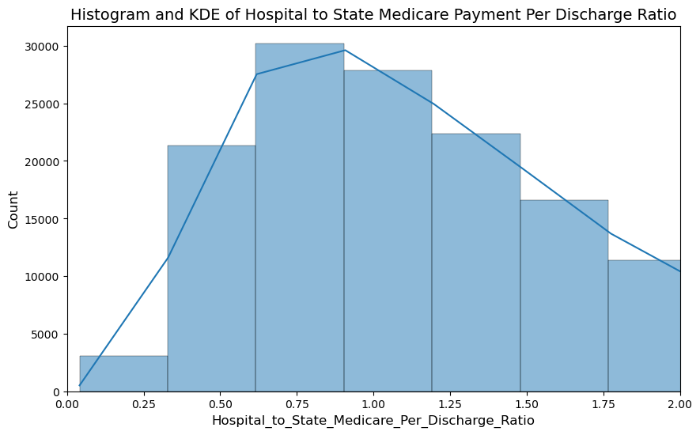

```python
# Calculate the hospital's average Medicare payment per discharge
F131415['Hospital_Avg_Medicare_Per_Discharge'] = F131415['Average_Medicare_Payment'] / F131415['Total_Discharges']

# Calculate Feature 13
F131415['Hospital_to_State_Medicare_Per_Discharge_Ratio'] = F131415['Hospital_Avg_Medicare_Per_Discharge'] / F131415['Avg_Medicare_Per_Discharge_ByStateDRG']

# Plot the distribution of the new feature
plt.figure(figsize=(10, 6))
sns.histplot(data=F131415, x='Hospital_to_State_Medicare_Per_Discharge_Ratio', kde=True, bins=200)
plt.xlim(0, 2)
plt.title("Histogram and KDE of Hospital to State Medicare Payment Per Discharge Ratio", fontsize=14)
plt.xlabel("Hospital_to_State_Medicare_Per_Discharge_Ratio", fontsize=12)
plt.ylabel("Count", fontsize=12)

plt.show()
```

##### The distribution for this feature centered around 1, indicating that most hospitals have payments close to the state average. Ratios significantly higher or lower than 1 may indicate anomalies.

#### Feature 14: Ratio of Average Medicare Payment by City per discharge to State Average Payment per discharge on DRG

##### This feature is to identify disparities at the city level. By comparing the average Medicare payment per discharge in a city to the state average within the same DRG, this feature helps to identify cost variations, highlighting cities where hospitals are charging significantly more or less per discharge compared to the state average.

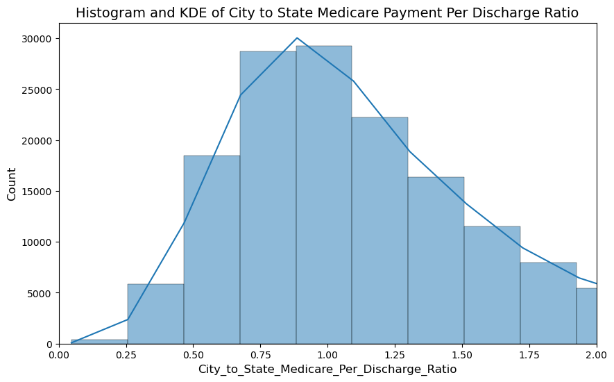

```python
# Calculate the average Medicare payment per discharge by city and DRG
city_avg_medicare_per_discharge = F131415.groupby(['Provider_City', 'DRG']).agg({
    'Average_Medicare_Payment': 'sum',
    'Total_Discharges': 'sum'
}).reset_index()

city_avg_medicare_per_discharge['City_Avg_Medicare_Per_Discharge'] = (
    city_avg_medicare_per_discharge['Average_Medicare_Payment'] /
    city_avg_medicare_per_discharge['Total_Discharges']
)

# Merge with the main dataset
F131415 = pd.merge(F131415, city_avg_medicare_per_discharge[['Provider_City', 'DRG', 'City_Avg_Medicare_Per_Discharge']],
                   on=['Provider_City', 'DRG'], how='left')

# Calculate Feature 14
F131415['City_to_State_Medicare_Per_Discharge_Ratio'] = F131415['City_Avg_Medicare_Per_Discharge'] / F131415['Avg_Medicare_Per_Discharge_ByStateDRG']

# Plot the distribution of the new feature
plt.figure(figsize=(10, 6))
sns.histplot(data=F131415, x='City_to_State_Medicare_Per_Discharge_Ratio', kde=True, bins=200)
plt.xlim(0, 2)
plt.title("Histogram and KDE of City to State Medicare Payment Per Discharge Ratio", fontsize=14)
plt.xlabel("City_to_State_Medicare_Per_Discharge_Ratio", fontsize=12)
plt.ylabel("Count", fontsize=12)

plt.show()
```

##### Most values here are centered around 1, indicating that city-level payments per discharge are generally close to the state average. Extreme deviations like greater than 1.5 or less than 0.5 might be identified as outliers.

#### Feature 15: Ratio of Provider's Average Medicare Payment per discharge to State Average Payment per discharge by DRG

##### The feature 15 is to identify how individal providers' Medicare payment practices compare to the state benchmarks. Providers that consistently charge more than the state average for similar cases, which may indicate potential overbilling or inefficiencies. And providers that charge less than the state average, which indicate cost-saving practices or underbilling.

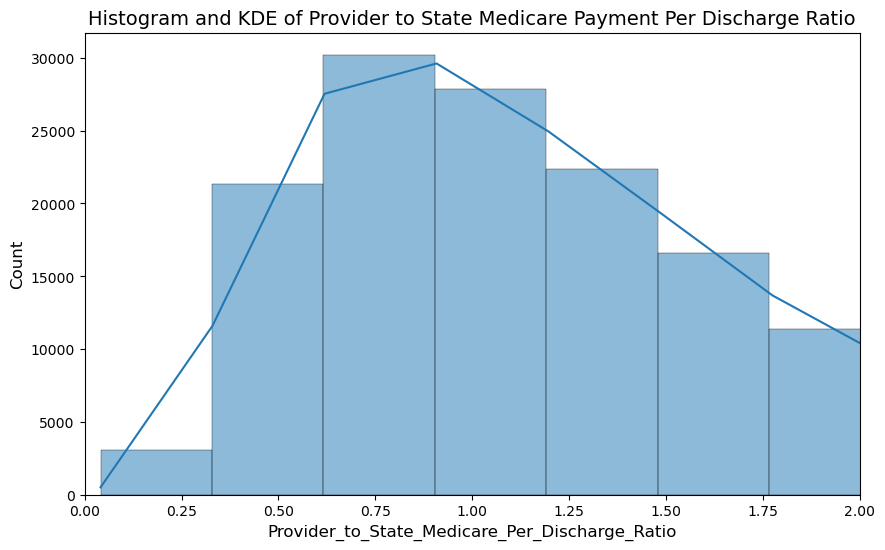

```python
# Calculate Feature 15
F131415['Provider_Avg_Medicare_Per_Discharge'] = F131415['Average_Medicare_Payment'] / F131415['Total_Discharges']
F131415['Provider_to_State_Medicare_Per_Discharge_Ratio'] = F131415['Provider_Avg_Medicare_Per_Discharge'] / F131415['Avg_Medicare_Per_Discharge_ByStateDRG']

# Plot the distribution of the new feature
plt.figure(figsize=(10, 6))
sns.histplot(data=F131415, x='Provider_to_State_Medicare_Per_Discharge_Ratio', kde=True, bins=200)
plt.xlim(0, 2)
plt.title("Histogram and KDE of Provider to State Medicare Payment Per Discharge Ratio", fontsize=14)
plt.xlabel("Provider_to_State_Medicare_Per_Discharge_Ratio", fontsize=12)
plt.ylabel("Count", fontsize=12)

plt.show()
```

##### It shows the distribution centered around 1, indicating the most providers' average Medicare payments are close to the state average. And outliers can be identified by observing values far from peak, especially on right side like ratios above 2, which may indicate the unusual high charges.